# Week 2

## The Spatial Stack

**Your R code:**

```r
sf::st_read("data.shp")      # I/O
sf::st_distance(a, b)        # Geometry
sf::st_transform(x, 4269)    # CRS
```

**📦 GDAL**

**File I/O**

- Format translators
- Reads/writes Shapefile, GeoJSON, GeoPackage, GeoTIFF
- Returns WKB geometry

**🧭 PROJ**

**Coordinate Systems**

- Transforms between 10,000+ CRS definitions
- Handles datum shifts & projections
- Underlies `st_transform()`

**⚙️ GEOS**

**Geometry Ops**

- Intersection, union, buffer, centroid
- Distance calculations
- Spatial predicates (`st_intersects()`)

## Why This Matters

Each library solves a hard problem:

| Library | Solves | Water Resources Example |
| --- | --- | --- |
| **GDAL** | “How do I read a shapefile or GeoPackage?” | Read NHD flowlines, USGS boundaries, stream gauges |
| **PROJ** | “How do I convert WGS84 to Albers?” | Transform NWIS gauges from GPS coordinates to federal projection |
| **GEOS** | “Is this point inside this polygon? What’s the distance?” | Snap gauge to nearest flowline, clip to basin |

If we had to write these from scratch in R, it would take years. Instead, spatial computing in R benefits from decades of work by the OSGeo community.

## The `sf` Wrapper

```r
sf::sf_extSoftVersion()
```

```
#>           GEOS           GDAL         proj.4 GDAL_with_GEOS     USE_PROJ_H
#>       "3.14.1"       "3.12.2"        "9.7.1"         "true"         "true"
#>           PROJ
#>        "9.7.1"
```

`sf` doesn’t reinvent these wheels. It:

1. **Calls GDAL** for I/O (`st_read()`, `st_write()`)
2. **Calls PROJ** for CRS transformations (`st_transform()`)
3. **Calls GEOS** for geometry operations (`st_distance()`, `st_buffer()`, spatial predicates)
4. **Wraps results** with S3 classes and methods so dplyr verbs (`filter()`, `mutate()`, `select()`) just work — same as tidyverse

**Note**

When you install the `sf` package on your machine, the R package manager compiles and links against GDAL, PROJ, and GEOS. If installation fails, it’s usually because one of these C/C++ libraries is missing from your system. This is why setting up spatial computing can be more complex than installing a pure-R package.

## What Is GDAL?

**GDAL** = Geospatial Data Abstraction Layer

A C++ library (developed by OSGeo, used by every GIS software) that:

1. **Abstracts** file formats — speaks shapefile, GeoJSON, GeoPackage, etc., but exposes the same API to your program
2. **Translates** between formats — convert any format to any other with one command
3. **Manages drivers** — each format has a “driver” (code that knows how to read/write that specific format)
4. **Handles metadata** — CRS, bounds, layer names, attribute types

```r
# GDAL (C++ library) <- drivers (one per format)
#     ├── Shapefile driver
#     ├── GeoJSON driver
#     ├── GeoPackage driver
#     ├── GeoTIFF driver
#     ├── NetCDF driver
#     └── ... 200+ more
```

When you call `st_read("data.shp")`, here’s what happens:

1. R/`sf` calls GDAL: *“Read this file”*
2. GDAL looks at the extension (.shp)
3. GDAL finds the Shapefile driver
4. The driver reads the .shp and its sidecars
5. GDAL returns data to `sf`
6. `sf` wraps it in an `sfc` geometry + `sf` object structure and hands it to your R code

**Note**

You don’t write GDAL code directly. But `st_read()` and `st_write()` are thin wrappers around GDAL. Understanding this explains why `st_read()` “just works” on 50+ formats and why format conversions are trivial in R but painful elsewhere.

## GDAL Drivers and Water Resources

```r
sf::st_drivers() # shows Format, type (vector/raster), open, write
```

Key drivers for water resources:

| Driver | Format | Extension | Common Use |
| --- | --- | --- | --- |
| **ESRI Shapefile** | Shapefile | .shp | USGS NHD, NOAA, boundaries |
| **GeoJSON** | GeoJSON | .geojson | Google APIs, web services |
| **GPKG** | GeoPackage | .gpkg | NHDPlus HR, modern data |
| **GTiff** | GeoTIFF | .tif | USGS 3DEP elevation, imagery |
| **netCDF** | NetCDF | .nc | NOAA climate grids |
| **HDF5** | HDF5 | .h5 | NASA satellite data |

**Important**

**GeoPackage** replaces Shapefiles: one file, complete metadata, SQLite-based. **Shapefiles** require sidecars (.shx, .dbf, .prj) and lack metadata. Use GeoPackage when possible.

## How Core Libraries Pass Data to R: WKT and WKB

When GDAL reads a file or GEOS performs an operation, it uses two standard encodings to pass geometry to R:

**Well-Known Text (WKT)** — human-readable (you’ll see this in error messages and discussions):

```r
x <- st_linestring(matrix(10:1, 5))
st_as_text(x)
```

```
#> [1] "LINESTRING (10 5, 9 4, 8 3, 7 2, 6 1)"
```

- LINESTRING = type; parentheses contain points; points separated by commas; coordinates separated by spaces

**Well-Known Binary (WKB)** — machine-readable, used internally by GDAL/GEOS for speed and lossless communication:

```r
st_as_binary(x)
```

```
#>  [1] 01 02 00 00 00 05 00 00 00 00 00 00 00 00 00 24 40 00 00 00 00 00 00 14 40
#> [26] 00 00 00 00 00 00 22 40 00 00 00 00 00 00 10 40 00 00 00 00 00 00 20 40 00
#> [51] 00 00 00 00 00 08 40 00 00 00 00 00 00 1c 40 00 00 00 00 00 00 00 40 00 00
#> [76] 00 00 00 00 18 40 00 00 00 00 00 00 f0 3f
```

**Note**

You rarely write WKT/WKB directly, but understanding they exist explains why `st_read()` “just works”—GDAL converts any format to WKB, `sf` wraps it as an R object, and the roundtrip is seamless.

# Simple Features

## Simple Features

## Today’s Data: Colorado Counties

```r
co
```

```
#> Simple feature collection with 64 features and 4 fields
#> Geometry type: MULTIPOLYGON
#> Dimension:     XY
#> Bounding box:  xmin: -109.0602 ymin: 36.99246 xmax: -102.0415 ymax: 41.00342
#> Geodetic CRS:  WGS 84
#> First 10 features:
#>    geoid       name      aland state_nm                       geometry
#> 1  08001      Adams 3021840487 Colorado MULTIPOLYGON (((-105.0532 3...
#> 2  08003    Alamosa 1871643028 Colorado MULTIPOLYGON (((-105.4855 3...
#> 3  08005   Arapahoe 2066438714 Colorado MULTIPOLYGON (((-103.7065 3...
#> 4  08007  Archuleta 3496712164 Colorado MULTIPOLYGON (((-107.1287 3...
#> 5  08009       Baca 6617400567 Colorado MULTIPOLYGON (((-102.0416 3...
#> 6  08011       Bent 3918255148 Colorado MULTIPOLYGON (((-102.7476 3...
#> 7  08013    Boulder 1881325109 Colorado MULTIPOLYGON (((-105.3978 3...
#> 8  08014 Broomfield   85386685 Colorado MULTIPOLYGON (((-105.1092 3...
#> 9  08015    Chaffee 2624715692 Colorado MULTIPOLYGON (((-105.9698 3...
#> 10 08017   Cheyenne 4605713960 Colorado MULTIPOLYGON (((-103.1729 3...
```

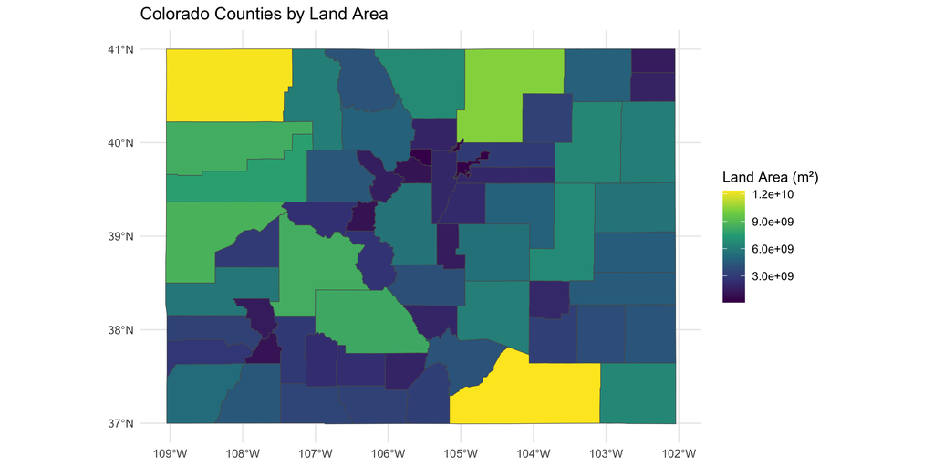

## What Is a Simple Feature?

- [Simple features](https://en.wikipedia.org/wiki/Simple_Features) (ISO 19125-1:2004) is a standard describing how real-world objects can be represented in computers, with emphasis on their *spatial geometry*
- It defines:
  1. A **class hierarchy** of geometry types
  2. A **set of operations** on those geometries
  3. **Binary and text encodings** for storage and transfer
- Widely implemented: PostGIS, ESRI ArcGIS, GDAL, GeoJSON — and `sf` in R
- A subset of simple features (the **big 7**) forms the [GeoJSON](http://geojson.org/) specification

## What Is a Feature?

A feature is a **thing in the real world** — a river, a gauge, a watershed, a county.

- Features often consist of other features:
  - A river *system* → a river → an outlet point
  - A watershed → sub-basins → individual reaches

The standard says: *“A simple feature has both **spatial** and **non-spatial** attributes. Spatial attributes are geometry valued.”*

- The **geometry** describes *where* the feature is and *how* it is represented
- A river’s geometry could be its watershed polygon, its mainstem linestring, or its outlet point — depending on the question

```r
str(co)
```

```
#> Classes 'sf' and 'data.frame':   64 obs. of  5 variables:
#>  $ geoid   : chr  "08001" "08003" "08005" "08007" ...
#>  $ name    : chr  "Adams" "Alamosa" "Arapahoe" "Archuleta" ...
#>  $ aland   : num  3.02e+09 1.87e+09 2.07e+09 3.50e+09 6.62e+09 ...
#>  $ state_nm: chr  "Colorado" "Colorado" "Colorado" "Colorado" ...
#>  $ geometry:sfc_MULTIPOLYGON of length 64; first list element: List of 1
#>   ..$ :List of 1
#>   .. ..$ : num [1:132, 1:2] -105 -105 -105 -105 -105 ...
#>   ..- attr(*, "class")= chr [1:3] "XY" "MULTIPOLYGON" "sfg"
#>  - attr(*, "sf_column")= chr "geometry"
#>  - attr(*, "agr")= Factor w/ 3 levels "constant","aggregate",..: NA NA NA NA
#>   ..- attr(*, "names")= chr [1:4] "geoid" "name" "aland" "state_nm"
```

## POINT

A point is composed of **one** coordinate pair in a specific coordinate system.

- Points have no length or area
- Example: a gauge location, a dam, a city

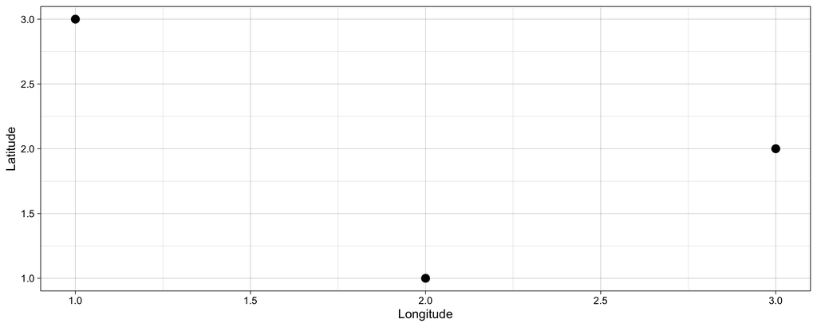

```r
ggplot() +
  geom_point(aes(x = c(1, 2, 3), y = c(3, 1, 2)), size = 3) +
  labs(x = "Longitude", y = "Latitude") +
  theme_linedraw()
```

## LINESTRING

A linestring is composed of an **ordered** sequence of two or more coordinate points.

- Points in a line are called **vertices** and explicitly define the connection between two points
- A line has **length**, but no area
- Example: a stream centerline, a river reach, a road

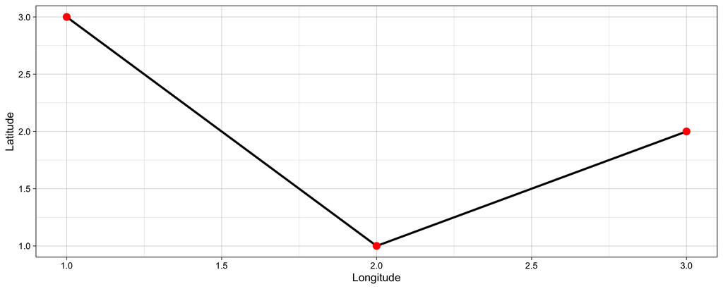

```r
ggplot() +
  geom_line(aes(x = c(1, 2, 3), y = c(3, 1, 2)), linewidth = 1) +
  geom_point(aes(x = c(1, 2, 3), y = c(3, 1, 2)), col = "red", size = 3) +
  labs(x = "Longitude", y = "Latitude") +
  theme_linedraw()
```

## POLYGON

A polygon is composed of 4 or more points whose starting and ending point are the same.

- Polygons enclose a **closed ring** (first point = last point)
- Polygons have both **length and area**
- Example: a watershed boundary, a county border, a floodplain

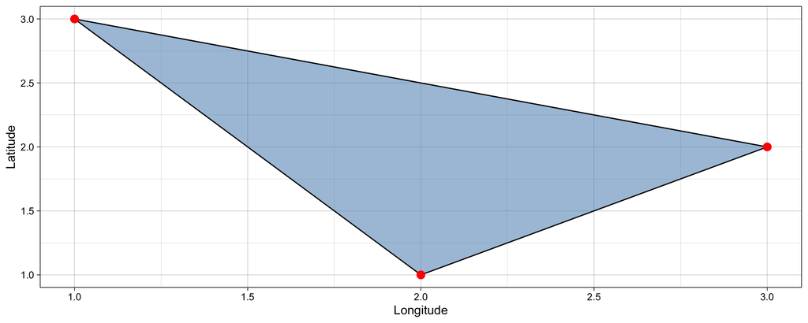

```r
ggplot() +
  geom_polygon(aes(x = c(1, 2, 3, 1), y = c(3, 1, 2, 3)), fill = "steelblue", alpha = 0.5, color = "black") +
  geom_point(aes(x = c(1, 2, 3), y = c(3, 1, 2)), col = "red", size = 3) +
  labs(x = "Longitude", y = "Latitude") +
  theme_linedraw()
```

## Multi-Geometries and Collections

**Multi-** variants are just **sets** of the same type:

- `MULTIPOINT` = set of points
- `MULTILINESTRING` = set of lines (e.g., a braided river system)
- `MULTIPOLYGON` = set of polygons (e.g., an island chain, a fragmented watershed)

**GEOMETRYCOLLECTION** = a set of mixed geometry types (rare, usually from intersections)

## The Big 7 Geometry Types

| Single | Description |
| --- | --- |
| `POINT` | Zero-dimensional — a single coordinate pair |
| `LINESTRING` | Sequence of points connected by straight line pieces — 1D |
| `POLYGON` | Closed ring with positive area — 2D; may have interior holes |

| Multi (same type) | Description |
| --- | --- |
| `MULTIPOINT` | Set of points |
| `MULTILINESTRING` | Set of linestrings |
| `MULTIPOLYGON` | Set of polygons |

| Mixed | Description |
| --- | --- |
| `GEOMETRYCOLLECTION` | Set of geometries of any type |

**Note**

These 7 types cover virtually everything in water resources work: gauge locations (POINT), stream reaches (LINESTRING), watershed boundaries (POLYGON), and their multi-feature equivalents.

## Dimensions

All geometries are composed of **points** defined in 2-, 3-, or 4-D space:

- **XY** — standard 2D coordinates (longitude, latitude or easting, northing)
- **XYZ** — adds altitude (elevation of stream bed, DEM surface)
- **XYM** — adds a measure attribute independent of the feature (e.g., streamflow at a vertex — rarely used)
- **XYZM** — both Z and M

Note: “dimension” here means *coordinate dimension* (XY vs XYZ), **not** whether the geometry has length or area:

```r
m1 <- rbind(c(8,1), c(2,5), c(3,2))
st_dimension(st_multipoint(m1))    # 0 — point set, no length
```

```
#> [1] 0
```

```r
st_dimension(st_linestring(m1))    # 1 — has length, no area
```

```
#> [1] 1
```

## Valid Geometries

**Rules for valid geometries:**

- **LINESTRING** — no self-intersections
- **POLYGON** — rings must be closed
- **POLYGON** — holes inside exterior only
- **POLYGON** — rings touch at points only
- **POLYGON** — no repeated paths

**Warning**

Run `st_is_valid()` to check your data. Fix invalid geometries with `st_make_valid()`.

## Invalid Examples

**Self-intersecting line:**

```r
x1 <- st_linestring(cbind(c(0,1,0,1),
                          c(0,1,1,0)))
st_is_simple(x1)  # FALSE
```

**Invalid polygon (crossing edges):**

```r
x2 <- st_polygon(list(cbind(
  c(0,1,1,1,0,0),
  c(0,0,1,0.6,1,0))))
st_is_valid(x2)  # FALSE
```

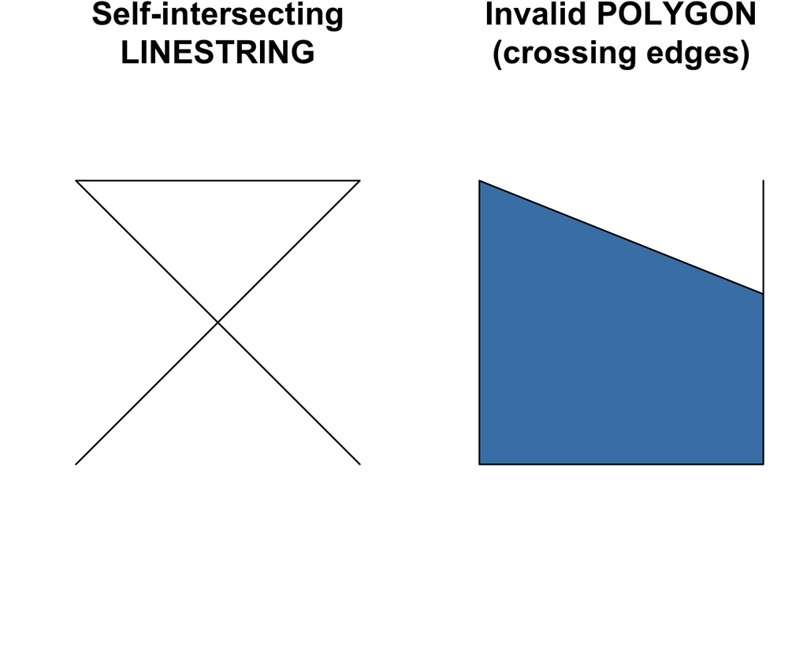

*These operations fail silently unless checked.*

## Empty Geometries

`EMPTY` geometries serve as “`NA`” placeholders for geometry types — they arise naturally from spatial operations:

```r
(e <- st_intersection(st_point(c(0,0)), st_point(c(1,1))))
```

```
#> GEOMETRYCOLLECTION EMPTY
```

```r
st_is_empty(e)
```

```
#> [1] TRUE
```

```r
plot(st_point(c(0,0)), pch = 16)
plot(st_point(c(1,1)), add = TRUE, col = 'red', pch = 16)
```

[output not shown]

# sfg → sfc → sf

## Storing Geometry: Nested Lists

Remember nested lists? A geometry is just **coordinates**:

```r
# One geometry: a pair of coordinates
c(x = 1, y = 2)

# Many geometries: nested list of coordinate pairs
list(list(c(1, 2)), list(c(3, 4)), list(c(5, 6)))
```

**R stores multiple geometries side-by-side this way:** Each row in a data.frame holds one geometry (which is a list of coordinates). This creates a **geometry column** — many rows, each with its own nested geometry.

- **One row** = one feature (with attributes + geometry)
- **Each row’s geometry** = one nested coordinate structure
- **All rows together** = a geometry list-column

## Three Classes, One Object

- 🟢 **sf** — a `data.frame` with feature attributes and a geometry column (class: `sf`)
- 🔴 **sfc** — the geometry list-column (set of geometries)
- 🔵 **sfg** — individual simple feature geometry (one geometry per feature)

**Important**

**This is the S3 class hierarchy in action.** `sf` is a subclass of `data.frame` adding the geometry column and specialized methods. When you call `filter()` on an `sf` object, R looks at its class and dispatches to the spatial-aware `filter.sf()` method, which respects the geometry column. Same pattern as `grouped_df` from tidyverse.

## `sfg`: Simple Feature Geometry

`sfg` objects carry the geometry for a **single feature**. Storage rules:

1. A single `POINT` → numeric vector
2. Points in a `LINESTRING` or `POLYGON` ring → matrix (each row = a point)
3. Any other set → list

Creator functions (rarely used in practice — you usually read existing data):

```r
(x <- st_point(c(1, 2)))
str(x)
```

```
#>  'XY' num [1:2] 1 2
```

```r
(x <- st_linestring(matrix(c(1,2,3,4), ncol = 2)))
str(x)
```

```
#>  'XY' num [1:2, 1:2] 1 2 3 4
```

## `sfg`: Class Structure

All geometry objects have an S3 class indicating (1) dimension, (2) type, (3) superclass:

```r
(pt  <- st_point(c(0, 1)))
attributes(pt)
```

```
#> $class
#> [1] "XY"    "POINT" "sfg"
```

```r
(pt2 <- st_point(c(0, 1, 4)))   # XYZ
attributes(pt2)
```

```
#> $class
#> [1] "XYZ"   "POINT" "sfg"
```

## `sfg`: Same Points, Different Meaning

The same coordinate matrix creates geometries with entirely different dimensionality:

```r
m1 <- rbind(c(8,1), c(2,5), c(3,2))

(mp <- st_multipoint(m1))   # zero-dimensional point set
(ls <- st_linestring(m1))   # one-dimensional line

st_dimension(mp); st_length(mp)
```

```
#> [1] 0
#> [1] 0
```

```r
st_dimension(ls); st_length(ls)
```

```
#> [1] 1
#> [1] 10.37338
```

## Mixed Geometries and Collections

When features have different geometry types, the type becomes `GEOMETRY`.

**Example: A collection with POINT + LINESTRING:**

```r
g <- st_sfc(st_point(c(0, 0)),
            st_linestring(rbind(c(0, 0), c(1, 1))))
```

**Filter by type with `st_is()`:**

```r
st_sf(geometry = g) |>
  filter(st_is(geometry, "LINESTRING"))   # keep only lines
```

```
#> Simple feature collection with 1 feature and 0 fields
#> Geometry type: LINESTRING
#> Dimension:     XY
#> Bounding box:  xmin: 0 ymin: 0 xmax: 1 ymax: 1
#> CRS:           NA
#>                geometry
#> 1 LINESTRING (0 0, 1 1)
```

**When intersections produce mixed types, use `st_collection_extract()`:**

```r
pt   <- st_point(c(1, 0))
ls   <- st_linestring(matrix(c(4, 3, 0, 0), ncol = 2))
poly <- st_polygon(list(matrix(c(5.5, 7, 7, 6, 5.5, 0, 0, -0.5, -0.5, 0), ncol = 2)))
collection <- st_geometrycollection(list(pt, ls, poly))

st_collection_extract(collection, "POLYGON")  # extract only polygons
```

## Conversion Between Types: `st_cast`

```r
(co1   <- filter(co, name == "Larimer")$geometry)
```

```
#> Geometry set for 1 feature
#> Geometry type: MULTIPOLYGON
#> Dimension:     XY
#> Bounding box:  xmin: -106.1954 ymin: 40.25778 xmax: -104.9431 ymax: 40.99844
#> Geodetic CRS:  WGS 84
```

```r
(co_ls <- st_cast(co1, "MULTILINESTRING"))
```

```
#> Geometry set for 1 feature
#> Geometry type: MULTILINESTRING
#> Dimension:     XY
#> Bounding box:  xmin: -106.1954 ymin: 40.25778 xmax: -104.9431 ymax: 40.99844
#> Geodetic CRS:  WGS 84
```

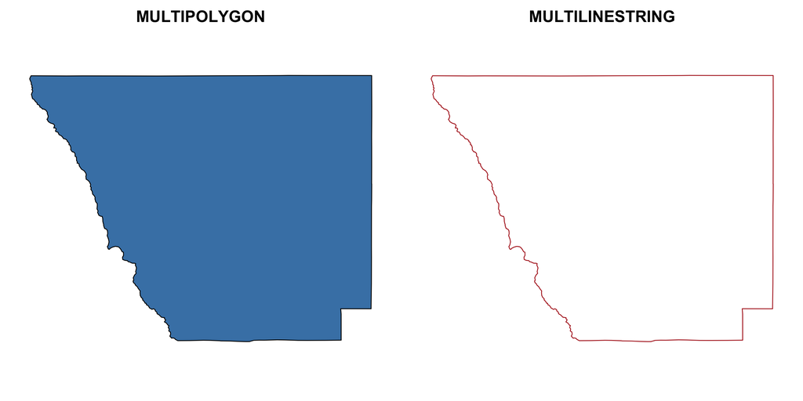

## Casting: Feature vs. Set Level

Casting operates at the **feature level**, not the set level:

```r
rbind(c(0,0), c(1,1), c(1,0), c(0,1)) |>
  st_linestring() |>
  st_cast("POINT")   # ⚠️ converts ONE line to ONE point — not what you want
```

To extract individual points, work at the **set level** (`sfc`):

```r
(p <- rbind(c(0,0), c(1,1), c(1,0), c(0,1)) |>
   st_linestring() |>
   st_sfc() |>           # create a SET of one geometry
   st_cast("POINT"))     # now produces 4 individual points
```

```
#> Geometry set for 4 features
#> Geometry type: POINT
#> Dimension:     XY
#> Bounding box:  xmin: 0 ymin: 0 xmax: 1 ymax: 1
#> CRS:           NA
```

## Sets of geometries

```r
rbind(c(0,0), c(1,1), c(1,0), c(0,1))
```

```
#>      [,1] [,2]
#> [1,]    0    0
#> [2,]    1    1
#> [3,]    1    0
#> [4,]    0    1
```

## Sets of geometries

```r
rbind(c(0,0), c(1,1), c(1,0), c(0,1)) |>
  st_linestring()
```

## Sets of geometries

```r
rbind(c(0,0), c(1,1), c(1,0), c(0,1)) |>
  st_linestring() |>
  st_sfc()
```

```
#> Geometry set for 1 feature
#> Geometry type: LINESTRING
#> Dimension:     XY
#> Bounding box:  xmin: 0 ymin: 0 xmax: 1 ymax: 1
#> CRS:           NA
```

## Sets of geometries

```r
rbind(c(0,0), c(1,1), c(1,0), c(0,1)) |>
  st_linestring() |>
  st_sfc() |>
  st_cast("POINT")
```

```
#> Geometry set for 4 features
#> Geometry type: POINT
#> Dimension:     XY
#> Bounding box:  xmin: 0 ymin: 0 xmax: 1 ymax: 1
#> CRS:           NA
```

## Sets of geometries

```r
rbind(c(0,0), c(1,1), c(1,0), c(0,1)) |>
  st_linestring() |>
  st_sfc() |>
  st_cast("POINT") ->
  p
```

## Combining and Dissolving Geometries

Two key operations for working with geometry sets:

**`st_combine()`** — joins geometries while **preserving** interior boundaries:

```r
(co_combined <- st_combine(co$geometry))
```

```
#> Geometry set for 1 feature
#> Geometry type: MULTIPOLYGON
#> Dimension:     XY
#> Bounding box:  xmin: -109.0602 ymin: 36.99246 xmax: -102.0415 ymax: 41.00342
#> Geodetic CRS:  WGS 84
```

**`st_union()`** — joins geometries and **dissolves** interior boundaries (merges into one feature):

```r
(co_unioned <- st_union(co$geometry))
```

```
#> Geometry set for 1 feature
#> Geometry type: POLYGON
#> Dimension:     XY
#> Bounding box:  xmin: -109.0602 ymin: 36.99246 xmax: -102.0415 ymax: 41.00342
#> Geodetic CRS:  WGS 84
```

## Visualizing Combine vs. Union

**st_combine** (boundaries preserved):

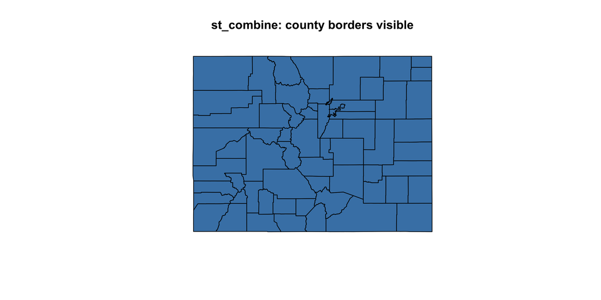

**st_union** (boundaries dissolved):

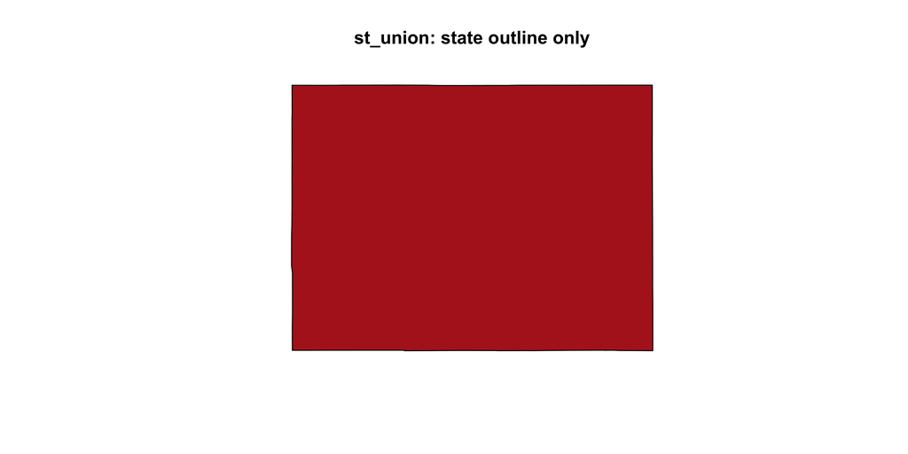

**Water resources example**: Use `st_combine()` to keep sub-basins separate, use `st_union()` to create a single merged basin outline.

## `sfc`: Geometry List-Columns

`st_sfc` creates sets of geometries — what becomes the sticky list-column in `sf` objects:

```r
(sfc <- st_sfc(st_point(c(0,1)), st_point(c(-3,2))))
```

```
#> Geometry set for 2 features
#> Geometry type: POINT
#> Dimension:     XY
#> Bounding box:  xmin: -3 ymin: 1 xmax: 0 ymax: 2
#> CRS:           NA
```

```r
class(sfc)
```

```
#> [1] "sfc_POINT" "sfc"
```

```r
attributes(sfc) |> names()
```

```
#> [1] "class"     "precision" "bbox"      "crs"       "n_empty"
```

The `sfc` object records for the **whole set**: precision, bounding box, CRS, and count of empty geometries.

## Combine + Cast: From Boundaries to Lines

You can combine geometries and then cast them to a different type — useful for creating line networks from polygon boundaries:

```r
co_borders_combined <- st_combine(co$geometry) |> st_cast("MULTILINESTRING")
co_borders_unioned  <- st_union(co$geometry) |> st_cast("MULTILINESTRING")
```

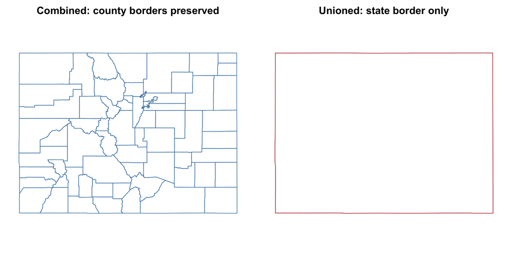

**Tip**

This distinction matters constantly in water resources: county boundaries vs. watershed boundaries, stream reaches vs. the river network, individual gauge catchments vs. the basin outline.

## CONUS: Combine vs. Union

```r
us_c_ml <- st_combine(conus) |> st_cast("MULTILINESTRING")
us_u_ml <- st_union(conus)   |> st_cast("MULTILINESTRING")
```

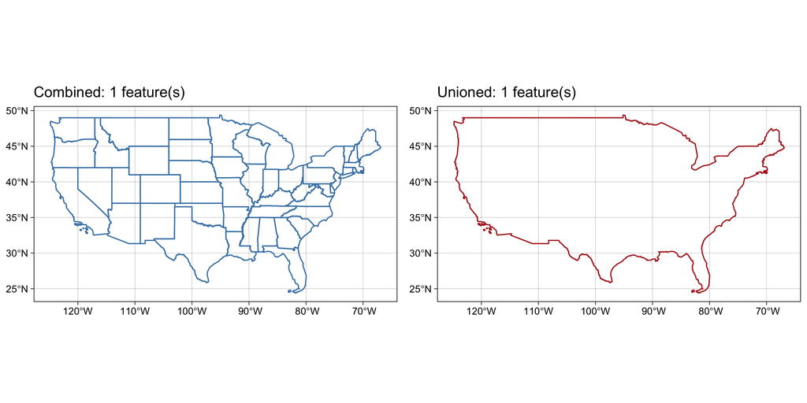

## Distance to Denver: Thinking About Feature Level

**Question**: how far is Denver from the nearest state border?

```r
denver_sf <- data.frame(y = 39.7392, x = -104.9903, name = "Denver") |>
  st_as_sf(coords = c("x", "y"), crs = 4326)
```

## Attempt 1: distance to states (polygons)

```r
conus
```

```
#> Simple feature collection with 49 features and 14 fields
#> Geometry type: MULTIPOLYGON
#> Dimension:     XY
#> Bounding box:  xmin: -124.8485 ymin: 24.39631 xmax: -66.88544 ymax: 49.38448
#> Geodetic CRS:  WGS 84
#> First 10 features:
#>    state_region state_division feature_code           state_name state_abbr
#> 1             3              6      1779775              Alabama         AL
#> 2             4              8      1779777              Arizona         AZ
#> 3             3              7      0068085             Arkansas         AR
#> 4             4              9      1779778           California         CA
#> 5             4              8      1779779             Colorado         CO
#> 6             1              1      1779780          Connecticut         CT
#> 7             3              5      1779781             Delaware         DE
#> 8             3              5      1702382 District of Columbia         DC
```

[output cut: 35 more lines]

## Attempt 1: distance to states (polygons)

```r
conus |>
  select(state_name)
```

```
#> Simple feature collection with 49 features and 1 field
#> Geometry type: MULTIPOLYGON
#> Dimension:     XY
#> Bounding box:  xmin: -124.8485 ymin: 24.39631 xmax: -66.88544 ymax: 49.38448
#> Geodetic CRS:  WGS 84
#> First 10 features:
#>              state_name                       geometry
#> 1               Alabama MULTIPOLYGON (((-85.4883 30...
#> 2               Arizona MULTIPOLYGON (((-110.7507 3...
#> 3              Arkansas MULTIPOLYGON (((-90.95577 3...
#> 4            California MULTIPOLYGON (((-116.1062 3...
#> 5              Colorado MULTIPOLYGON (((-105.155 36...
#> 6           Connecticut MULTIPOLYGON (((-72.5279 41...
#> 7              Delaware MULTIPOLYGON (((-75.13846 3...
#> 8  District of Columbia MULTIPOLYGON (((-77.00244 3...
#> 9               Florida MULTIPOLYGON (((-83.10874 2...
#> 10              Georgia MULTIPOLYGON (((-81.09538 3...
```

## Attempt 1: distance to states (polygons)

```r
conus |>
  select(state_name) %>%
  mutate(dist = st_distance(., denver_sf))
```

```
#> Simple feature collection with 49 features and 2 fields
#> Geometry type: MULTIPOLYGON
#> Dimension:     XY
#> Bounding box:  xmin: -124.8485 ymin: 24.39631 xmax: -66.88544 ymax: 49.38448
#> Geodetic CRS:  WGS 84
#> First 10 features:
#>              state_name                       geometry          dist
#> 1               Alabama MULTIPOLYGON (((-85.4883 30... 1571007.9 [m]
#> 2               Arizona MULTIPOLYGON (((-110.7507 3...  466602.9 [m]
#> 3              Arkansas MULTIPOLYGON (((-90.95577 3...  975519.6 [m]
#> 4            California MULTIPOLYGON (((-116.1062 3... 1000950.5 [m]
#> 5              Colorado MULTIPOLYGON (((-105.155 36...       0.0 [m]
#> 6           Connecticut MULTIPOLYGON (((-72.5279 41... 2636635.7 [m]
#> 7              Delaware MULTIPOLYGON (((-75.13846 3... 2485997.1 [m]
#> 8  District of Columbia MULTIPOLYGON (((-77.00244 3... 2388920.9 [m]
#> 9               Florida MULTIPOLYGON (((-83.10874 2... 1847447.4 [m]
#> 10              Georgia MULTIPOLYGON (((-81.09538 3... 1788781.6 [m]
```

## Attempt 1: distance to states (polygons)

```r
conus |>
  select(state_name) %>%
  mutate(dist = st_distance(., denver_sf)) |>
  slice_min(dist, n = 3)
```

```
#> Simple feature collection with 3 features and 2 fields
#> Geometry type: MULTIPOLYGON
#> Dimension:     XY
#> Bounding box:  xmin: -111.0546 ymin: 36.99246 xmax: -95.30829 ymax: 45.00582
#> Geodetic CRS:  WGS 84
#>   state_name         dist                       geometry
#> 1   Colorado      0.0 [m] MULTIPOLYGON (((-105.155 36...
#> 2    Wyoming 140002.6 [m] MULTIPOLYGON (((-106.3212 4...
#> 3   Nebraska 161243.2 [m] MULTIPOLYGON (((-95.93779 4...
```

## Attempt 1: distance to states (polygons)

```r
conus |>
  select(state_name) %>%
  mutate(dist = st_distance(., denver_sf)) |>
  slice_min(dist, n = 3) ->
  state_data
```

## Attempt 2: cast to lines first

```r
conus
```

```
#> Simple feature collection with 49 features and 14 fields
#> Geometry type: MULTIPOLYGON
#> Dimension:     XY
#> Bounding box:  xmin: -124.8485 ymin: 24.39631 xmax: -66.88544 ymax: 49.38448
#> Geodetic CRS:  WGS 84
#> First 10 features:
#>    state_region state_division feature_code           state_name state_abbr
#> 1             3              6      1779775              Alabama         AL
#> 2             4              8      1779777              Arizona         AZ
#> 3             3              7      0068085             Arkansas         AR
#> 4             4              9      1779778           California         CA
#> 5             4              8      1779779             Colorado         CO
#> 6             1              1      1779780          Connecticut         CT
#> 7             3              5      1779781             Delaware         DE
#> 8             3              5      1702382 District of Columbia         DC
```

[output cut: 35 more lines]

## Attempt 2: cast to lines first

```r
conus |>
  select(state_name)
```

```
#> Simple feature collection with 49 features and 1 field
#> Geometry type: MULTIPOLYGON
#> Dimension:     XY
#> Bounding box:  xmin: -124.8485 ymin: 24.39631 xmax: -66.88544 ymax: 49.38448
#> Geodetic CRS:  WGS 84
#> First 10 features:
#>              state_name                       geometry
#> 1               Alabama MULTIPOLYGON (((-85.4883 30...
#> 2               Arizona MULTIPOLYGON (((-110.7507 3...
#> 3              Arkansas MULTIPOLYGON (((-90.95577 3...
#> 4            California MULTIPOLYGON (((-116.1062 3...
#> 5              Colorado MULTIPOLYGON (((-105.155 36...
#> 6           Connecticut MULTIPOLYGON (((-72.5279 41...
#> 7              Delaware MULTIPOLYGON (((-75.13846 3...
#> 8  District of Columbia MULTIPOLYGON (((-77.00244 3...
#> 9               Florida MULTIPOLYGON (((-83.10874 2...
#> 10              Georgia MULTIPOLYGON (((-81.09538 3...
```

## Attempt 2: cast to lines first

```r
conus |>
  select(state_name) |>
  st_cast("MULTILINESTRING")
```

```
#> Simple feature collection with 49 features and 1 field
#> Geometry type: MULTILINESTRING
#> Dimension:     XY
#> Bounding box:  xmin: -124.8485 ymin: 24.39631 xmax: -66.88544 ymax: 49.38448
#> Geodetic CRS:  WGS 84
#> First 10 features:
#>              state_name                       geometry
#> 1               Alabama MULTILINESTRING ((-85.4883 ...
#> 2               Arizona MULTILINESTRING ((-110.7507...
#> 3              Arkansas MULTILINESTRING ((-90.95577...
#> 4            California MULTILINESTRING ((-116.1062...
#> 5              Colorado MULTILINESTRING ((-105.155 ...
#> 6           Connecticut MULTILINESTRING ((-72.5279 ...
#> 7              Delaware MULTILINESTRING ((-75.13846...
#> 8  District of Columbia MULTILINESTRING ((-77.00244...
#> 9               Florida MULTILINESTRING ((-83.10874...
#> 10              Georgia MULTILINESTRING ((-81.09538...
```

## Attempt 2: cast to lines first

```r
conus |>
  select(state_name) |>
  st_cast("MULTILINESTRING") %>%
  mutate(dist = st_distance(., denver_sf))
```

```
#> Simple feature collection with 49 features and 2 fields
#> Geometry type: MULTILINESTRING
#> Dimension:     XY
#> Bounding box:  xmin: -124.8485 ymin: 24.39631 xmax: -66.88544 ymax: 49.38448
#> Geodetic CRS:  WGS 84
#> First 10 features:
#>              state_name                       geometry          dist
#> 1               Alabama MULTILINESTRING ((-85.4883 ... 1571007.9 [m]
#> 2               Arizona MULTILINESTRING ((-110.7507...  466602.9 [m]
#> 3              Arkansas MULTILINESTRING ((-90.95577...  975519.6 [m]
#> 4            California MULTILINESTRING ((-116.1062... 1000950.5 [m]
#> 5              Colorado MULTILINESTRING ((-105.155 ...  140002.6 [m]
#> 6           Connecticut MULTILINESTRING ((-72.5279 ... 2636635.7 [m]
#> 7              Delaware MULTILINESTRING ((-75.13846... 2485997.1 [m]
#> 8  District of Columbia MULTILINESTRING ((-77.00244... 2388920.9 [m]
#> 9               Florida MULTILINESTRING ((-83.10874... 1847447.4 [m]
#> 10              Georgia MULTILINESTRING ((-81.09538... 1788781.6 [m]
```

## Attempt 2: cast to lines first

```r
conus |>
  select(state_name) |>
  st_cast("MULTILINESTRING") %>%
  mutate(dist = st_distance(., denver_sf)) |>
  slice_min(dist, n = 3)
```

```
#> Simple feature collection with 3 features and 2 fields
#> Geometry type: MULTILINESTRING
#> Dimension:     XY
#> Bounding box:  xmin: -111.0546 ymin: 36.99246 xmax: -95.30829 ymax: 45.00582
#> Geodetic CRS:  WGS 84
#>   state_name         dist                       geometry
#> 1   Colorado 140002.6 [m] MULTILINESTRING ((-105.155 ...
#> 2    Wyoming 140002.6 [m] MULTILINESTRING ((-106.3212...
#> 3   Nebraska 161243.2 [m] MULTILINESTRING ((-95.93779...
```

## The Right Feature Level

```r
st_distance(denver_sf, st_cast(st_combine(conus), "MULTILINESTRING"))
```

```
#> Units: [m]
#>          [,1]
#> [1,] 140002.6
```

# The `sf` Object

## `sf`: Attributes + Geometry

```r
co
```

```
#> Simple feature collection with 64 features and 4 fields
#> Geometry type: MULTIPOLYGON
#> Dimension:     XY
#> Bounding box:  xmin: -109.0602 ymin: 36.99246 xmax: -102.0415 ymax: 41.00342
#> Geodetic CRS:  WGS 84
#> First 10 features:
#>    geoid       name      aland state_nm                       geometry
#> 1  08001      Adams 3021840487 Colorado MULTIPOLYGON (((-105.0532 3...
#> 2  08003    Alamosa 1871643028 Colorado MULTIPOLYGON (((-105.4855 3...
#> 3  08005   Arapahoe 2066438714 Colorado MULTIPOLYGON (((-103.7065 3...
#> 4  08007  Archuleta 3496712164 Colorado MULTIPOLYGON (((-107.1287 3...
#> 5  08009       Baca 6617400567 Colorado MULTIPOLYGON (((-102.0416 3...
#> 6  08011       Bent 3918255148 Colorado MULTIPOLYGON (((-102.7476 3...
#> 7  08013    Boulder 1881325109 Colorado MULTIPOLYGON (((-105.3978 3...
#> 8  08014 Broomfield   85386685 Colorado MULTIPOLYGON (((-105.1092 3...
#> 9  08015    Chaffee 2624715692 Colorado MULTIPOLYGON (((-105.9698 3...
#> 10 08017   Cheyenne 4605713960 Colorado MULTIPOLYGON (((-103.1729 3...
```

```r
class(co)
```

```
#> [1] "sf"         "data.frame"
```

```r
attr(co, "sf_column")
```

```
#> [1] "geometry"
```

An `sf` object is a `data.frame` with one special list-column: the geometry. It extends `data.frame` with spatial awareness.

## Sticky Geometry

The geometry column **persists through dplyr operations**:

```r
co |>
  select(name) |>
  slice(1:2)   # geometry comes along
```

```
#> Simple feature collection with 2 features and 1 field
#> Geometry type: MULTIPOLYGON
#> Dimension:     XY
#> Bounding box:  xmin: -106.0393 ymin: 37.3562 xmax: -103.7057 ymax: 40.00137
#> Geodetic CRS:  WGS 84
#>      name                       geometry
#> 1   Adams MULTIPOLYGON (((-105.0532 3...
#> 2 Alamosa MULTIPOLYGON (((-105.4855 3...
```

Drop it explicitly when you don’t need it:

```r
co |> st_drop_geometry() |> select(name) |> slice(1:2)
```

```
#>      name
#> 1   Adams
#> 2 Alamosa
```

## Plotting `sf` Objects with ggplot2

`geom_sf()` is the bridge between `sf` and `ggplot2` — everything from last week works:

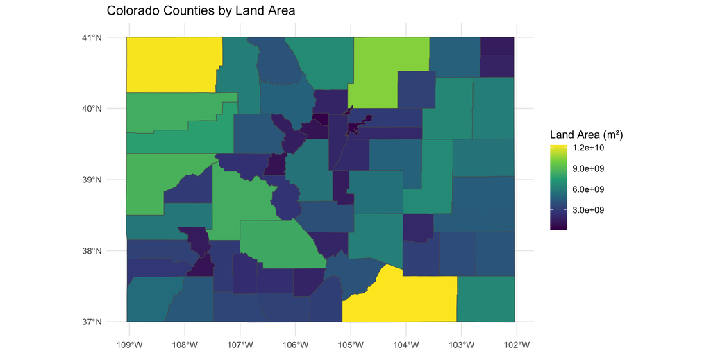

```r
ggplot(data = co) +
  geom_sf(aes(fill = aland)) +
  scale_fill_viridis_c(name = "Land Area (m²)") +
  labs(title = "Colorado Counties by Land Area") +
  theme_minimal()
```

All `dplyr` verbs work on `sf` objects first, then pipe into `ggplot`:

```r
co |>
  filter(name == "Larimer") |>
  ggplot() + geom_sf(fill = "#1E4D2B") + theme_void()
```

## The Sticky Geometry Structure

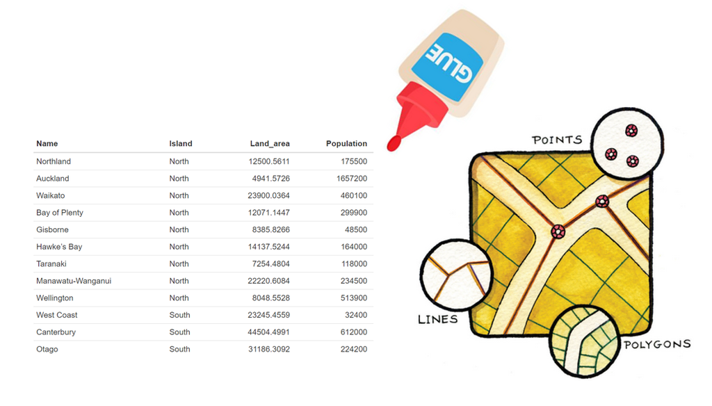

The geometry binding is unique — unlike `bind_cols()` or `cbind()`, the `sfc` list-column carries CRS, bounding box, and precision metadata that regular column binding does not.

## Simple Features: What You’ve Learned

You now understand:

- The **seven geometry types** — POINT, LINESTRING, POLYGON, and their multi-equivalents
- The **class hierarchy** — `sfg` (individual geometry) → `sfc` (set) → `sf` (dataframe with sticky geometry)
- **Valid geometries** — self-intersecting lines and invalid polygons break spatial operations silently
- **WKT and WKB** — human-readable and machine-readable encodings
- **Casting and dissolving** — changing geometry type and boundary representation
- **Sticky geometry in dplyr** — `sf` objects work naturally with pipes, filters, and ggplot

Now a 5-minute break, then: **What makes these coordinates actually *spatial*?** We’ll cover the Coordinate Reference System — the foundation that anchors every spatial operation.

# ☕ Break

## 5 Minutes

Back in 5. Next: coordinate systems, projections, and the three-part system (ellipsoid, datum, prime meridian) that determines whether your spatial analysis is correct or silently wrong.

# Coordinate Systems

## What Makes Spatial Data Spatial?

The geometry alone is meaningless without knowing **where on Earth** those coordinates refer to. That’s the job of the Coordinate Reference System.

## Coordinate Reference Systems

A **Coordinate Reference System (CRS)** defines how spatial features relate to the surface of the Earth.

Two broad types:

- **Geographic Coordinate System (GCS)** — locations on the *curved* surface of the Earth, measured in angular units (degrees)
- **Projected Coordinate System (PCS)** — locations on a *flat* surface, measured in linear units (meters, feet)

In `sf`, three tools:

| Function | Does |
| --- | --- |
| `st_crs()` | Retrieve CRS from an `sf` or `sfc` object |
| `st_set_crs()` | Set or replace CRS (no coordinate transformation) |
| `st_transform()` | Transform coordinates from one CRS to another |

## Geographic Coordinate Systems

A GCS identifies locations on the **curved** surface of the Earth using angular measurements from the center:

- **Latitude** — vertical angle (North/South from equator)
- **Longitude** — horizontal angle (East/West from prime meridian)
- North and East are positive; South and West are negative

A GCS is defined by three components:

1. **Ellipsoid** — the mathematical model of Earth’s shape (flattened sphere, not perfect)
2. **Datum** — how the ellipsoid is anchored to the real Earth (locally fitted or globally centered)
3. **Prime meridian** — the origin of longitude (Greenwich, 0°E/W)

Why this matters: two datasets may use the same coordinates but different datums. The difference is small (sub-meter) but compounds in spatial joins and distance calculations.

## Common Datums in Water Resources

Three datums account for most US data:

| Datum | Acronym | Used by | Typical error vs. NAD83 |
| --- | --- | --- | --- |
| North American Datum 1983 | NAD83 | NHDPlus, most USGS vector data | Reference datum |
| World Geodetic System 1984 | WGS84 | GPS, NWIS gauges, web maps | <1 meter in CONUS |
| NAD27 (historic) | NAD27 | Legacy sources only | Can be 100+ meters off |

**Note**

NAD83 and WGS84 differ by less than 1 meter for most of CONUS. But they are *not* the same CRS. Mixing them without explicit transformation introduces sub-meter errors that compound in spatial joins. Always check with `st_crs(a) == st_crs(b)` before joining.

## Projected Coordinate Systems

A **Projected Coordinate System (PCS)** transforms the curved Earth onto a 2D plane. Every transformation introduces **distortion**.

**Three main projection families:**

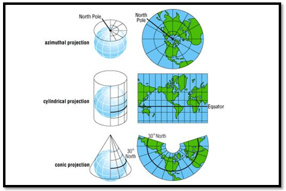

- **Planar** — flat surface touches globe at a point (best for polar regions)
- **Cylindrical** — cylinder wraps around globe (world maps, Mercator)
- **Conic** — cone around globe (mid-latitude areas, CONUS)

## Spatial Properties and Distortion

Each type of projection prioritizes one property at the cost of others:

| Property | Preserved by | Used for |
| --- | --- | --- |
| **Area** | Equal-area (Albers) | Accurate area calculations, choropleth maps |
| **Distance** | Equidistant | Distance from a fixed center point |
| **Shape** | Conformal (Mercator) | Navigation, preserving local angles |
| **Direction** | Azimuthal | Navigation from a pole |

## Projection Choice: Water Resources Defaults

For CONUS analysis, use these defaults:

**Important**

- **Computing area** (choropleth maps, watershed statistics) → **EPSG:5070** (Albers Equal Area). This is the standard federal projection for CONUS.
- **Measuring distance** (gauge to outlet, confluences, dam spacing) → Keep data in geographic (WGS84, EPSG:4326) and use `st_distance()` with default S2 spherical geometry — it’s geodesic and correct.
- **Sub-state local analysis** → Use a local UTM zone (e.g., NAD83 / UTM zone 13) if you need projected planar distance.
- **Visualization/mapping** → Use whatever looks right for your region (Web Mercator for web, Albers for print).

## EPSG Codes and PROJ Strings

`sf` stores CRS in two ways:

- **EPSG code** — integer ID for a known CRS (e.g., `4326` = WGS84 geographic)
- **PROJ4 string** — generic text description understood by the PROJ library

Common codes for water resources work:

| EPSG | Name | Use |
| --- | --- | --- |
| 4326 | WGS84 geographic | GPS coordinates, web maps, NWIS gauges |
| 4269 | NAD83 geographic | NHDPlus, most USGS vector data |
| 5070 | NAD83 / Conus Albers | Area calculations, CONUS-wide analysis |
| 26913–26915 | UTM NAD83 zones 13–15 | Local/state-level distance calculations |

Practical rule: Use EPSG:5070 for CONUS area calculations; use a local UTM (e.g., NAD83 / UTM zones) for sub-state analyses.

## Checking and Setting CRS

```r
st_crs(conus)$epsg
```

```
#> [1] 4326
```

```r
st_crs(conus)$proj4string
```

```
#> [1] "+proj=longlat +datum=WGS84 +no_defs"
```

```r
st_crs(conus)$datum
```

```
#> [1] "WGS84"
```

```r
conus5070 <- st_transform(conus, 5070)
st_crs(conus5070)$epsg
```

```
#> [1] 5070
```

```r
st_crs(conus5070)$proj4string
```

```
#> [1] "+proj=aea +lat_0=23 +lon_0=-96 +lat_1=29.5 +lat_2=45.5 +x_0=0 +y_0=0 +datum=NAD83 +units=m +no_defs"
```

## Visualizing Projections

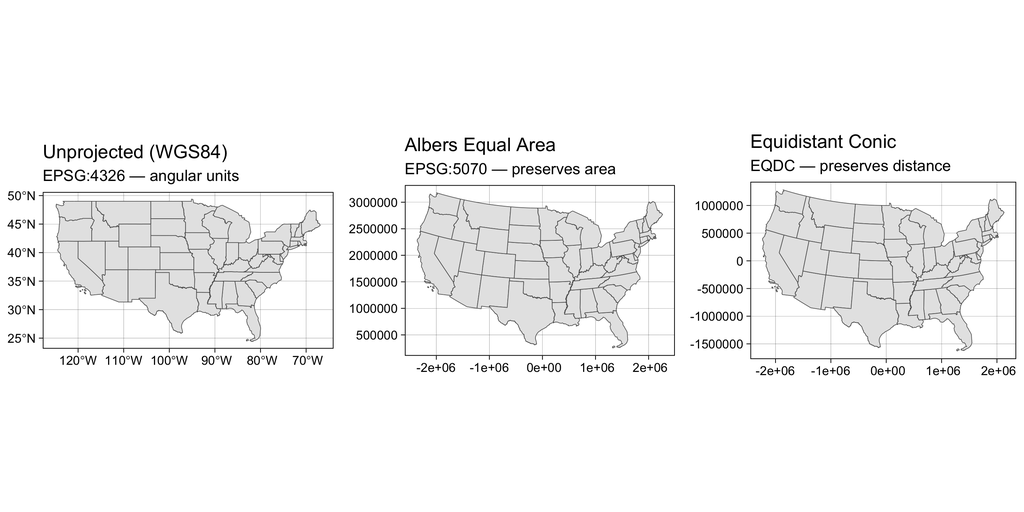

## #1 Reproducibility Habit: Always Check CRS

Before **any** spatial operation — joins, distance calculations, area calculations — verify CRS match:

```r
# Guard pattern: check before joining
if (st_crs(gauges) != st_crs(flowlines)) {
  flowlines <- st_transform(flowlines, st_crs(gauges))
}

# Or use the equality check
st_crs(gauges) == st_crs(flowlines)  # must be TRUE
```

**Real example**: NWIS gauges (WGS84, EPSG:4326) + NHD flowlines (NAD83, EPSG:4269):

```r
st_crs(4326) == st_crs(4269)    # FALSE — they are not the same!
```

```
#> [1] FALSE
```

They look similar (sub-meter differences in CONUS), but snapping a point to a line or computing a distance will be subtly wrong without transformation.

**Important**

`sf` will warn you about CRS mismatch but **won’t stop you**. The result will execute and look plausible — but numbers will be wrong. Build the guard-check habit now.

# Measurements

## Geodesic vs. Planar Measurements

**Geodesic distance**: shortest path on an ellipsoid — true Earth surface distance.

**Planar distance**: Euclidean distance in projected coordinates — fast but introduces error.

```r
pts <- data.frame(y = c(40.7128, 34.4208), x = c(-74.0060, -119.6982)) |>
  st_as_sf(coords = c("x", "y"), crs = 4326)

st_distance(pts)                    # Geodesic: ~3,962 km (correct)
st_distance(st_transform(pts, 5070))# Planar: ~3,950 km (distorted)
```

**Important**

**For water resources: use geodesic (default)**. In geographic CRS, `st_distance()` automatically computes geodesic (spherical) distances — correct for continental scales.

**Note**

`sf` uses geodesic by default in geographic CRS. Toggle S2 with `sf::sf_use_s2(TRUE/FALSE)` for fine control (rarely needed).

**Note**

## What Is S2?

**S2** is Google’s spherical geometry library — a modern C++ implementation for accurate calculations on a sphere/ellipsoid.

`sf` uses S2 under the hood when data is in geographic coordinates (e.g., WGS84). Instead of flattening Earth to a 2D plane (which introduces distortion), S2 works directly with spherical coordinates:

**Important**

S2 is **automatic**: if your data is in geographic coordinates, `st_distance()`, `st_intersects()`, and other spatial operations use S2 geodesic calculations by default. You don’t need to do anything.

## Controlling S2: When and How

S2 is the right default for water resources work (continental scales, mixed coordinate systems), but you can toggle it for specialized cases:

```r
# Disable S2 (use GEOS planar geometry instead)
sf::sf_use_s2(FALSE)

# Re-enable S2
sf::sf_use_s2(TRUE)

# Check current setting
sf::sf_use_s2()
```

**When to disable S2:** - Very small local areas (< 10 km) where planar error is negligible and you want marginal speed gains - Specialized geometric algorithms that require GEOS planar operations (rare in practice)

**Leave S2 enabled (default):** - Continental and larger scales (your typical water resources workflow) - Mixing geographic and projected data - When correctness matters more than squeezing out microseconds

## Units as an S3 Class — Workflow

Results carry **units** as an S3 class attribute — both powerful for correctness and a source of confusion in practice.

```r
class(conus)
```

```
#> [1] "sf"         "data.frame"
```

```r
attributes(conus)
```

```
#> $names
#>  [1] "state_region"           "state_division"         "feature_code"
#>  [4] "state_name"             "state_abbr"             "name"
#>  [7] "fip_class"              "tiger_class"            "combined_area_code"
#> [10] "metropolitan_area_code" "functional_status"      "land_area"
#> [13] "water_area"             "fip_code"               "geometry"
#>
#> $row.names
#>  [1]  1  2  3  4  5  6  7  8  9 10 11 12 13 14 15 16 17 18 19 20 21 22 23 24 25
#> [26] 26 27 28 29 30 31 32 33 34 35 36 37 38 39 40 41 42 43 44 45 46 47 48 49
#>
#> $sf_column
#> [1] "geometry"
#>
#> $agr
#>           state_region         state_division           feature_code
#>                   <NA>                   <NA>                   <NA>
#>             state_name             state_abbr                   name
#>                   <NA>                   <NA>                   <NA>
#>              fip_class            tiger_class     combined_area_code
#>                   <NA>                   <NA>                   <NA>
#> metropolitan_area_code      functional_status              land_area
#>                   <NA>                   <NA>                   <NA>
#>             water_area               fip_code
#>                   <NA>                   <NA>
#> Levels: constant aggregate identity
#>
#> $class
#> [1] "sf"         "data.frame"
```

…

```r
class(st_length(conus))
```

```
#> [1] "units"
```

```r
attributes(st_length(conus)) |> unlist()
```

```
#> units.numerator           class
#>             "m"         "units"
```

## Units Workflow: Create → Convert → Drop

Create units naturally from measurements, convert between units, then drop before plotting or filtering:

Convert between units with the `units` package:

```r
co <- AOI::aoi_get(state = "CO")
(l = st_length(st_cast(co, "MULTILINESTRING")))
```

```
#> 2100640 [m]
```

```r
units::set_units(l, "km")
```

```
#> 2100.64 [km]
```

```r
units::set_units(l, "mile")
```

```
#> 1305.277 [mile]
```

```r
(a = st_area(co))
```

```
#> 2.69382e+11 [m^2]
```

```r
units::set_units(a, "ha")
```

```
#> 26938196 [ha]
```

```r
units::set_units(a, "km2")
```

```
#> 269382 [km^2]
```

Strip units when needed for arithmetic or plotting:

```r
units::drop_units(l)
```

```
#> [1] 2100640
```

```r
as.numeric(l)
```

```
#> [1] 2100640
```

## Units Are a Class — Know the Rules

Units enforce dimensional correctness but can surprise you:

```r
st_length(conus) + 100   # can't add meters + unitless number

filter(cities, dist_to_border < 160)  # may warn or fail
```

The corrected patterns:

```r
# Create numeric version for filtering/plotting
cities <- cities |>
  mutate(dist_to_border_km = as.numeric(units::set_units(dist_to_border, "km")))

# Now filter and plot safely
cities |>
  filter(dist_to_border_km < 160) |>
  ggplot(aes(color = dist_to_border_km)) +
  geom_sf()
```

# Getting Spatial Data into R

## Building `sf` from a CSV

When coordinates are stored as numeric columns in a CSV — the most common format for point data from APIs, sensors, and databases — use `st_as_sf()`:

```r
cities <- read_csv("data/uscities.csv") |>
  st_as_sf(coords = c("lng", "lat"),  # column names: X first, then Y
           crs    = 4326)             # raw lat/lon is almost always WGS84
```

Three things to always specify:

1. `coords =` — column names in order X (longitude), Y (latitude)
2. `crs =` — the CRS the raw numbers **are in** (not what you want them in)
3. Then `st_transform()` to convert to your analysis CRS

## Full pipeline:

```r
cities <- read_csv("data/uscities.csv") |>
  st_as_sf(coords = c("lng", "lat"), crs = 4326) |>
  st_transform(5070)                # reproject for distance analysis
```

## End-to-End: CSV → Filtered → Transformed → Measured

This is the complete workflow to compute the distance from every city to the national border:

```r
# Pre-compute boundary in projected space (outside the pipeline)
boundary <- st_cast(st_union(st_transform(conus, 5070)), "MULTILINESTRING")

# Main workflow: read, build, transform, measure
system.time({
cities <- read_csv("data/uscities.csv", show_col_types =FALSE) |>
  st_as_sf(coords = c("lng", "lat"), crs = 4326) |>
  st_transform(5070) %>%
  mutate(
    dist_to_border_m = st_distance(., boundary),
    dist_to_border_km = units::set_units(dist_to_border_m, "km")
  )
})
```

```
#>    user  system elapsed
#>   1.665   0.018   1.633
```

```r
# user  system elapsed
# 1.648   0.014   1.677
```

Key takeaways: - **Build sf**: CSV coordinates + CRS they’re in → `st_as_sf()` - **Transform**: project to EPSG:5070 for measurements - **Measure**: distance returns units object; convert as needed - **Reuse**: pass pre-computed boundary to `st_distance()` — clean, fast, readable

## Common Pitfalls ⚠️

### Pitfall: Distances in Geographic Space

```r
boundary <- st_cast(st_union(conus),"MULTILINESTRING")

cities <- read_csv("data/uscities.csv") |>
  st_as_sf(coords = c("lng", "lat"), crs = 4326) %>%
  mutate(dist = st_distance(., boundary))

# user    system  elapsed
# 80.763  0.300   81.055
```

**Rule**: Transform geometry to projected CRS before expensive operations like `st_union()`, `st_intersection()`, etc.

### Pitfall 2: Comparing Units

```r
dist <- st_distance(cities, boundary)  # Returns [m]

filter(cities, dist < 100)              # ❌ ERROR
filter(cities, as.numeric(dist) < 100)  # ✅ CORRECT
```

**Rule**: Drop units with `as.numeric()` before comparisons.

**Important**

**Principle: Choose CRS strategically.**

- **Geographic (4326)** by default for input/output (standard data format)
- **Project immediately** to EPSG:5070 (or your region’s standard) for analysis
- **Pre-compute expensive operations** (union, clip, buffer) in projected space *outside* the data pipeline
- This respects both correctness (geodesic) and performance (planar operations where they matter)

# Visualizing Spatial Data

## `geom_sf()`: The Foundation

`geom_sf()` is ggplot2’s spatial geometry layer. It automatically extracts coordinates from the `geometry` column and plots them. **No need to specify `x` and `y` aesthetics.**

**Points**

```r
ggplot(cities) +
  geom_sf(color = "navy", size = 1)
```

**Polygons**

```r
ggplot(conus) +
  geom_sf(fill = "lightblue", color = "black")
```

**Key advantage**: All standard ggplot2 aesthetics work — `color`, `fill`, `size`, `alpha`, `linetype`, etc. And you can layer multiple `geom_sf()` calls:

```r
ggplot() +
  geom_sf(data = conus, fill = "white") +
  geom_sf(data = st_filter(cities, st_transform(conus, 5070)), color = "red", size = 0.1) +
  theme_void()
```

**Tip**

**Always add `theme_void()`** to remove axes, gridlines, and background — maps don’t need Cartesian coordinates.

## `ggrepel`: Non-Overlapping Labels

`ggrepel` solves label collision — essential any time you label points on a map:

```r
library(ggrepel)

ggplot() +
  geom_sf(data = conus, fill = "white") +
  geom_sf(data = st_filter(cities, st_transform(conus, 5070)), color = "red", size = 0.1) +
  ggrepel::geom_label_repel(
    data = filter(cities, city == "Denver"),
    aes(geometry = geometry, label = city),
    stat = "sf_coordinates",  # extracts coordinates from sf geometry
    size = 3
  ) +
  theme_void()
```

`stat = "sf_coordinates"` is the key argument — it tells ggrepel to extract X/Y from the geometry column rather than expecting explicit `x` and `y` aesthetics. Without it, you get an error.

## `gghighlight`: Emphasize a Subset

`gghighlight` greys out features that do not meet a condition, keeping them as spatial context:

```r
library(gghighlight)

ggplot() +
  geom_sf(data = conus) +
  geom_sf(data = st_filter(cities, st_transform(conus, 5070)),
          aes(color = as.numeric(dist_to_border_km)),
          size = 0.3) +
  gghighlight(as.numeric(dist_to_border_km) < 100) +
  scale_color_gradient(low = "orange", high = "darkred") +
  labs(title = "Cities within 100 km of the national border",
       color = "Distance (km)") +
  theme_void()
```

Features outside the condition are rendered in grey at reduced opacity — they provide spatial context without competing visually with the highlighted subset. Works with any `geom_*` — points, lines, polygons.

# Wrapping Up

## What We Covered

**Simple Features**

- The ISO standard and its R implementation
- The big 7 geometry types
- sfg → sfc → sf class hierarchy
- WKT / WKB encodings
- Casting, combining, dissolving
- Sticky geometry + `geom_sf()`

**Coordinate Systems**

**Measurements**

- Geodesic vs. planar distance
- `st_distance()`, `st_area()`, `st_length()`
- Units as an S3 class — `set_units()`, `drop_units()`
- Converting and dropping units

**Key habits built today:**

1. `st_is_valid()` on every dataset you read
2. `st_crs(a) == st_crs(b)` before every spatial join
3. Use equal-area CRS for areas, equidistant for distances
4. `as.numeric()` before filtering on unit quantities

## Next Week

**Week 3: Spatial Predicates & Joins** — relationships between geometries, filtering by space, and combining data sources